# EXST 7151

```r
#burn in period of 3000
burnin = 3000
int_mcmc <- int_mcmc[(burnin+1):n.sim]
slope_mcmc <- slope_mcmc[(burnin+1):n.sim]
var_mcmc <- var_mcmc[(burnin+1):n.sim]
```

```
## [1] "----------------- Posterior Information on: The Intercept ----------------"
## [1] "The 95 % credible interval for the Intercept  is from 157.72 to 200.3 ."
## [1] "The 99 % credible interval for the Intercept  is from 152.06 to 205.86 ."
## [1] "The mean of the of posterior distribution for the Intercept is:  179.138 ."
## [1] "The median of the of posterior distribution for the Intercept is:  179.472 ."
## [1] "The variance of the of posterior distribution for the Intercept  is:  121.77 ."
```

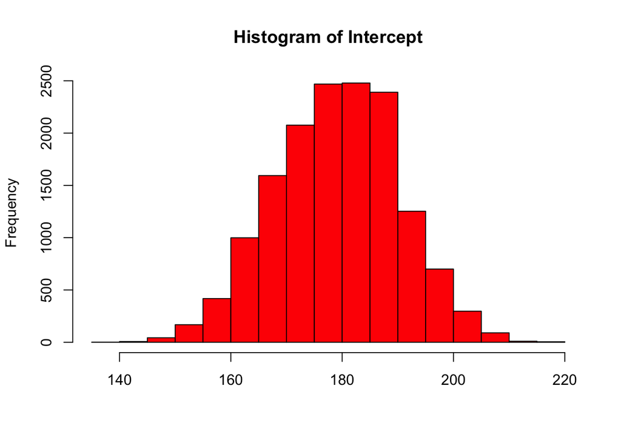

```
## [1] "----------------- Posterior Information on: The Slope ----------------"
## [1] "The 95 % credible interval for the Slope  is from -0.97 to 16.85 ."
## [1] "The 99 % credible interval for the Slope  is from -3.57 to 19.95 ."
## [1] "The mean of the of posterior distribution for the Slope is:  7.78 ."
## [1] "The median of the of posterior distribution for the Slope is:  7.84 ."
## [1] "The variance of the of posterior distribution for the Slope  is:  20.484 ."
```

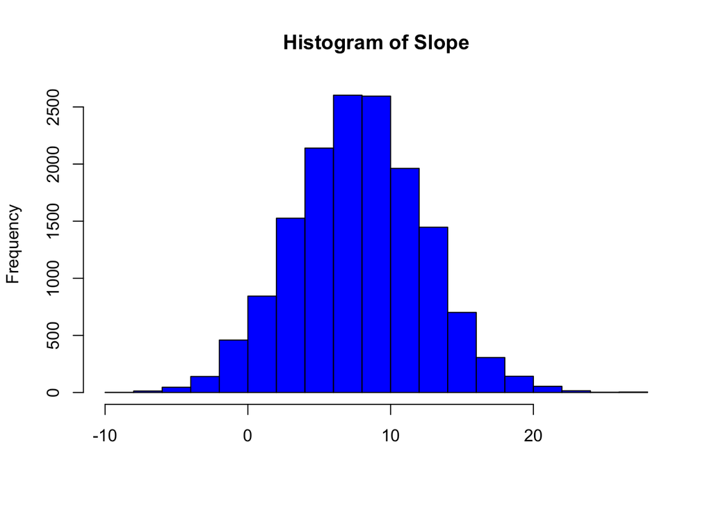

```
## [1] "----------------- Posterior Information on: The Variance ----------------"
## [1] "The 95 % credible interval for the Variance  is from 0.01 to 215.68 ."
## [1] "The 99 % credible interval for the Variance  is from 0.01 to 339.79 ."
## [1] "The mean of the of posterior distribution for the Variance is:  44.448 ."
## [1] "The median of the of posterior distribution for the Variance is:  21.122 ."
## [1] "The variance of the of posterior distribution for the Variance  is:  3761.305 ."
```

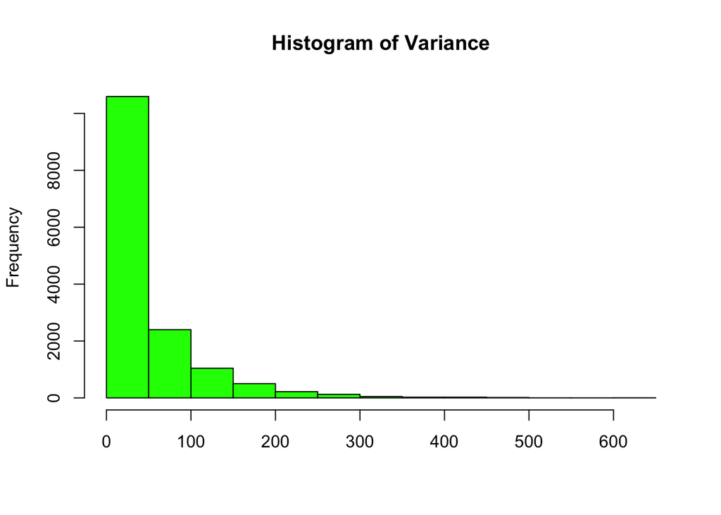

```r
for (i in 1:length(theta.mcmc)) {
  print(paste("----------------- Posterior Information on: The",names(theta.mcmc[i]),"----------------"))
  print(paste("The 95 % credible interval for the",names(theta.mcmc)[i]," is from",round(quantile(theta.mcmc[[i]],c(.025,.975))[1],digits=2), "to", round(quantile(theta.mcmc[[i]],c(.025,.975))[2],digits=2), "."))
  print(paste("The 99 % credible interval for the",names(theta.mcmc)[i]," is from",round(quantile(theta.mcmc[[i]],c(.005,.995))[1],digits=2), "to", round(quantile(theta.mcmc[[i]],c(.005,.995))[2],digits=2), "."))
  print(paste("The mean of the of posterior distribution for the",names(theta.mcmc)[i],"is: ", round(mean(theta.mcmc[[i]]),digits=3), "."))
  print(paste("The median of the of posterior distribution for the",names(theta.mcmc)[i],"is: ", round(median(theta.mcmc[[i]]),digits=3), "."))
  print(paste("The variance of the of posterior distribution for the",names(theta.mcmc)[i]," is: ", round(var(theta.mcmc[[i]]),digits=3), "."))
  hist(theta.mcmc[[i]], main=paste("Histogram of",names(theta.mcmc)[i]), xlab = "", col=colors[i])
}
```

# ‘Final’ Model

Recall, $y_i$ = $\beta_0$ + $\beta_1$X + $\epsilon_i$, $\epsilon_i$ ~ N(0, $\sigma^2$)  
The posterior distributions of $\beta_0$, $\beta_1$, and $\sigma^2$ produce infinitely many possible values for each parameter. Thus, if we would like **only one** value, as opposed to distrbution of values, we would need to select a point estimate from this distribution as a “best guess”.  
Selecting the mean of each posterior would minimized the L2 norm (squared difference) while selecting the median of each posterior would minimized the L1 norm (absolute difference). I will choose to minimize the L2 norm.  
Additionally, I would like to compare my ‘final model’ to OLS from a frequentist perspective. **Note: $\hat(\sigma^2)$ is an estimate of Mean Squared Error.**

```r
freqmodel = lm(y~x)
fc = c(freqmodel$coefficients, sum(freqmodel$residuals^2)/(length(freqmodel$residuals)-length(freqmodel$coefficients)))
names(fc) = c("Intercept", "Slope", "Mean Squared Error")
bc = c(mean(int_mcmc),mean(slope_mcmc),mean(var_mcmc))
names(bc) = c("Intercept", "Slope", "Variance")
for (i in 1:length(fc)) {
  print(paste("The Frequentist estimate for", names(fc)[i], "is: ", round(fc[i],digits = 2)))
}
```

```
## [1] "The Frequentist estimate for Intercept is:  187.19"
## [1] "The Frequentist estimate for Slope is:  6.53"
## [1] "The Frequentist estimate for Mean Squared Error is:  158.48"
```

```r
print("-------------------------------------------------------")
```

```
## [1] "-------------------------------------------------------"
```

```r
for (i in 1:length(fc)) {
  print(paste("A Bayesian estimate for", names(bc)[i], "is: ", round(bc[i],digits = 2)))
}
```

```
## [1] "A Bayesian estimate for Intercept is:  179.02"
## [1] "A Bayesian estimate for Slope is:  7.74"
## [1] "A Bayesian estimate for Variance is:  45.4"
```

# Conclusions

The Frequntist and this Bayesian estimate for intercept and slope are quite close (in this instance). However, the estimate for variance are quite different.  
Centering the x data allowed for an alternate choice of prior since the parameter space for $\beta_0$ changed.  
Prior predictive checks are a good way to see what a model believes before it has seen any data.  
Choosing **different** point estimates from the posteriors result in a **different** ‘final’ model choice.